# Palmerpenguins Analysis

“Itunu Fatokunbo”

2022-06-16

We analyzed the palmerspenguins dataset. The dataset is based on three species of penguins (Adelie,Chinstrap and Gentoo), found on three islands (Biscoe, Dream and Torgersen) in Palmer Archipelago.

## Loading of Packages and Dataset

```r
library(tidyverse)
```

```r
library(tidyr)
library(dplyr)
library(ggplot2)
library(palmerpenguins)
```

```r
data("penguins")

glimpse(penguins)
```

```
## Rows: 344
## Columns: 8
## $ species           <fct> Adelie, Adelie, Adelie, Adelie, Adelie, Adelie, Adel…
## $ island            <fct> Torgersen, Torgersen, Torgersen, Torgersen, Torgerse…
## $ bill_length_mm    <dbl> 39.1, 39.5, 40.3, NA, 36.7, 39.3, 38.9, 39.2, 34.1, …
## $ bill_depth_mm     <dbl> 18.7, 17.4, 18.0, NA, 19.3, 20.6, 17.8, 19.6, 18.1, …
## $ flipper_length_mm <int> 181, 186, 195, NA, 193, 190, 181, 195, 193, 190, 186…
## $ body_mass_g       <int> 3750, 3800, 3250, NA, 3450, 3650, 3625, 4675, 3475, …
## $ sex               <fct> male, female, female, NA, female, male, female, male…
## $ year              <int> 2007, 2007, 2007, 2007, 2007, 2007, 2007, 2007, 2007…
```

```r
summary(penguins)
```

```
##       species          island    bill_length_mm  bill_depth_mm
##  Adelie   :152   Biscoe   :168   Min.   :32.10   Min.   :13.10
##  Chinstrap: 68   Dream    :124   1st Qu.:39.23   1st Qu.:15.60
##  Gentoo   :124   Torgersen: 52   Median :44.45   Median :17.30
##                                  Mean   :43.92   Mean   :17.15
##                                  3rd Qu.:48.50   3rd Qu.:18.70
##                                  Max.   :59.60   Max.   :21.50
##                                  NA's   :2       NA's   :2
##  flipper_length_mm  body_mass_g       sex           year
##  Min.   :172.0     Min.   :2700   female:165   Min.   :2007
##  1st Qu.:190.0     1st Qu.:3550   male  :168   1st Qu.:2007
##  Median :197.0     Median :4050   NA's  : 11   Median :2008
##  Mean   :200.9     Mean   :4202                Mean   :2008
##  3rd Qu.:213.0     3rd Qu.:4750                3rd Qu.:2009
##  Max.   :231.0     Max.   :6300                Max.   :2009
##  NA's   :2         NA's   :2
```

## Cleaning and Analyzing of Dataset

```r
penguins2 <- penguins %>% drop_na()

penguins2[duplicated(penguins2), ]
```

```
## # A tibble: 0 × 8
## # … with 8 variables: species <fct>, island <fct>, bill_length_mm <dbl>,
## #   bill_depth_mm <dbl>, flipper_length_mm <int>, body_mass_g <int>, sex <fct>,
## #   year <int>
```

```r
glimpse(penguins2)
```

```
## Rows: 333
## Columns: 8
## $ species           <fct> Adelie, Adelie, Adelie, Adelie, Adelie, Adelie, Adel…
## $ island            <fct> Torgersen, Torgersen, Torgersen, Torgersen, Torgerse…
## $ bill_length_mm    <dbl> 39.1, 39.5, 40.3, 36.7, 39.3, 38.9, 39.2, 41.1, 38.6…
## $ bill_depth_mm     <dbl> 18.7, 17.4, 18.0, 19.3, 20.6, 17.8, 19.6, 17.6, 21.2…
## $ flipper_length_mm <int> 181, 186, 195, 193, 190, 181, 195, 182, 191, 198, 18…
## $ body_mass_g       <int> 3750, 3800, 3250, 3450, 3650, 3625, 4675, 3200, 3800…
## $ sex               <fct> male, female, female, female, male, female, male, fe…
## $ year              <int> 2007, 2007, 2007, 2007, 2007, 2007, 2007, 2007, 2007…
```

```r
penguins2 %>% count(species)
```

```
## # A tibble: 3 × 2
##   species       n
##   <fct>     <int>
## 1 Adelie      146
## 2 Chinstrap    68
## 3 Gentoo      119
```

```r
penguins2 %>% count(species, sex)
```

```
## # A tibble: 6 × 3
##   species   sex        n
##   <fct>     <fct>  <int>
## 1 Adelie    female    73
## 2 Adelie    male      73
## 3 Chinstrap female    34
## 4 Chinstrap male      34
## 5 Gentoo    female    58
## 6 Gentoo    male      61
```

```r
penguins2 %>% count(species, island)
```

```
## # A tibble: 5 × 3
##   species   island        n
##   <fct>     <fct>     <int>
## 1 Adelie    Biscoe       44
## 2 Adelie    Dream        55
## 3 Adelie    Torgersen    47
## 4 Chinstrap Dream        68
## 5 Gentoo    Biscoe      119
```

```r
penguins2 %>% group_by(species) %>% count(sex, island)
```

```
## # A tibble: 10 × 4
## # Groups:   species [3]
##    species   sex    island        n
##    <fct>     <fct>  <fct>     <int>
##  1 Adelie    female Biscoe       22
##  2 Adelie    female Dream        27
##  3 Adelie    female Torgersen    24
##  4 Adelie    male   Biscoe       22
##  5 Adelie    male   Dream        28
##  6 Adelie    male   Torgersen    23
##  7 Chinstrap female Dream        34
##  8 Chinstrap male   Dream        34
##  9 Gentoo    female Biscoe       58
## 10 Gentoo    male   Biscoe       61
```

## Visualizations

### Count of species

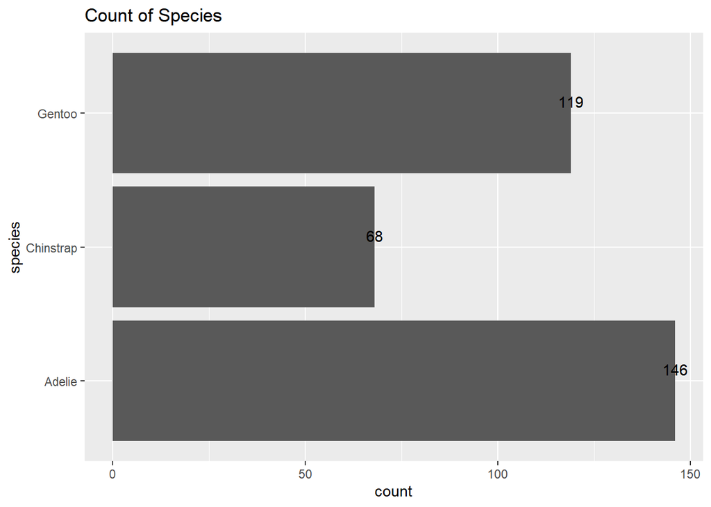

```r
ggplot(data = penguins2, aes(x=species)) + geom_bar() +
  labs(title = "Count of Species") + geom_text(aes(label=after_stat(count)),
   stat = 'count', vjust=-0.5) + coord_flip()
```

### Species by Sex

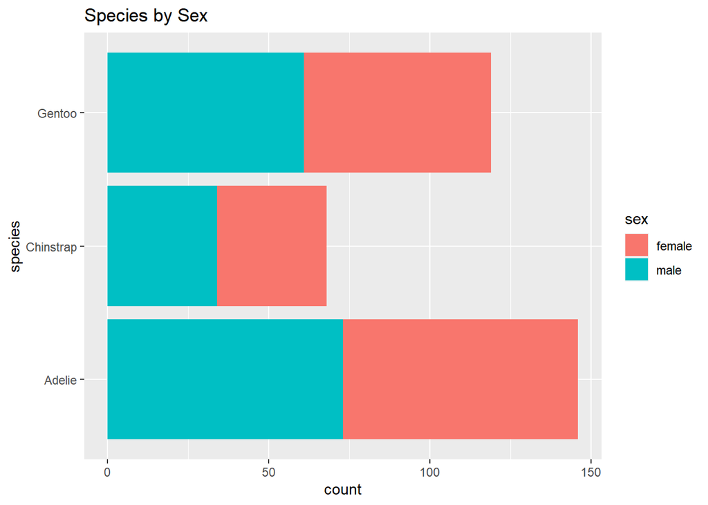

```r
ggplot(data = penguins2, mapping = aes(x=species,  fill=sex)) + geom_bar() +
  labs(title = "Species by Sex") + coord_flip()
```

### Species by Island

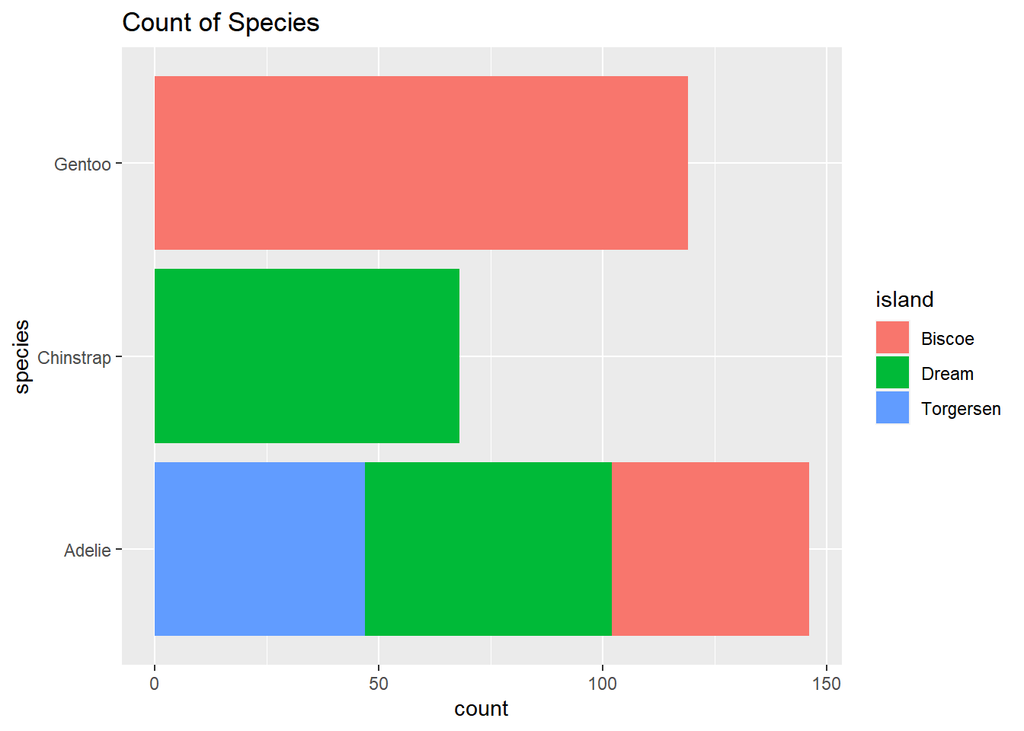

```r
ggplot(data = penguins2, aes(x=species, fill=island)) + geom_bar() +
  labs(title = "Count of Species") + coord_flip()
```

### Body Mass and Bill Depth

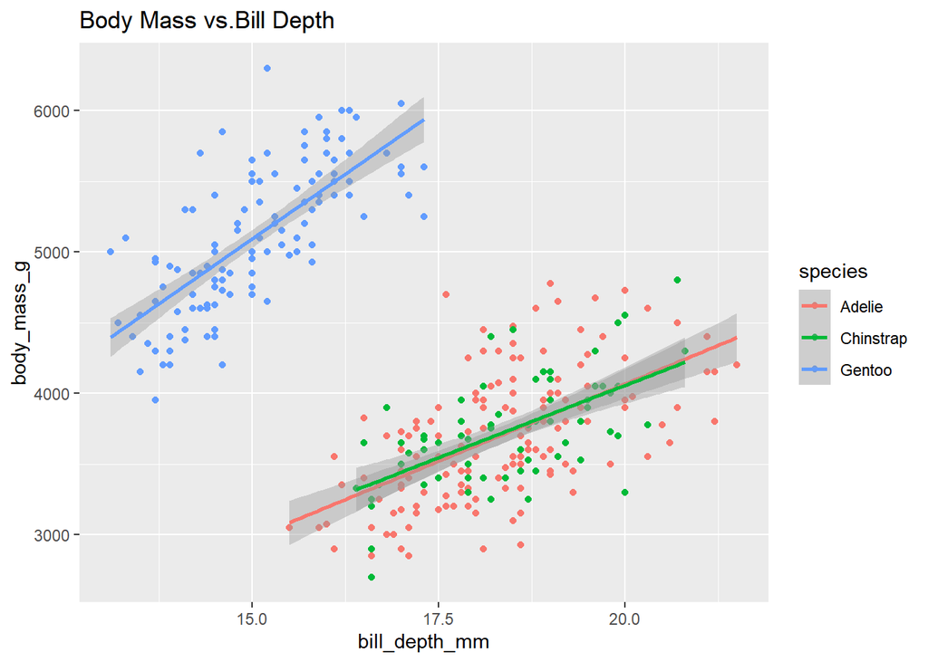

```r
ggplot(data = penguins2, mapping = aes(x= bill_depth_mm,
  y=body_mass_g, color=species))  + geom_point() +
  labs(title = "Body Mass vs.Bill Depth") +
  geom_smooth(formula='y ~ x', method = "lm")
```

### Flipper Length and Bill Length

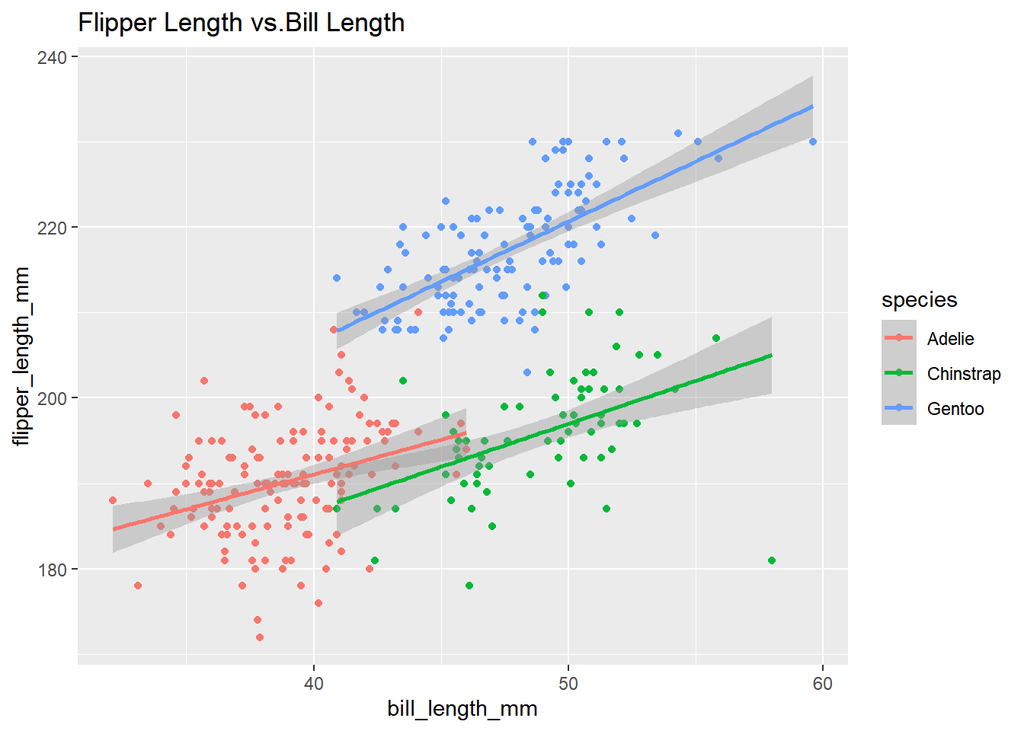

```r
ggplot(data = penguins2, mapping = aes(x= bill_length_mm,
  y=flipper_length_mm, color=species))  + geom_point() +
  labs(title = "Flipper Length vs.Bill Length") +
  geom_smooth(formula='y ~ x', method = "lm")
```

### Flipper Length and Bill Depth

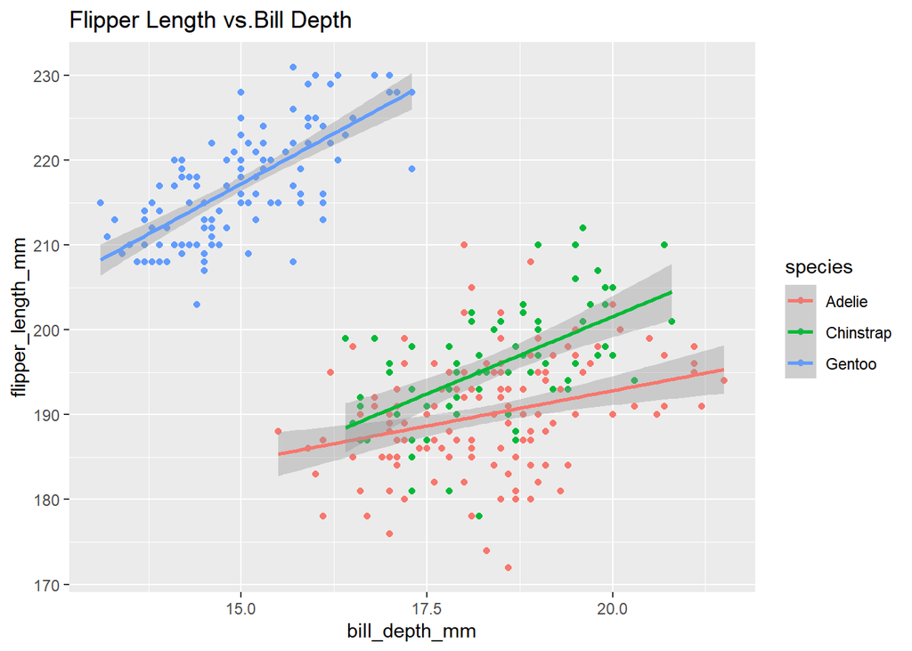

```r
ggplot(data = penguins2, mapping = aes(x= bill_depth_mm,
  y=flipper_length_mm, color=species))  + geom_point() +
  labs(title = "Flipper Length vs.Bill Depth") +
  geom_smooth(formula='y ~ x', method = "lm")
```

### Body Mass and Flipper Length

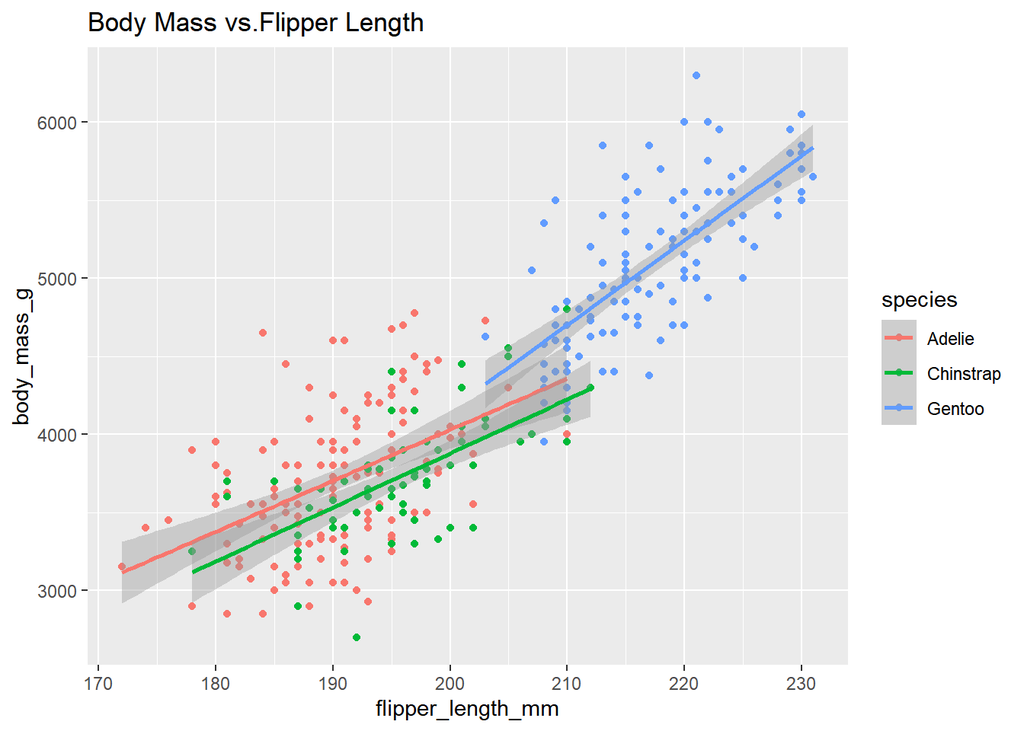

```r
ggplot(data = penguins2, mapping = aes(x= flipper_length_mm,
  y=body_mass_g, color=species))  + geom_point() +
  labs(title = "Body Mass vs.Flipper Length ") +
  geom_smooth(formula='y ~ x', method = "lm")
```

### Body Mass and Bill Length

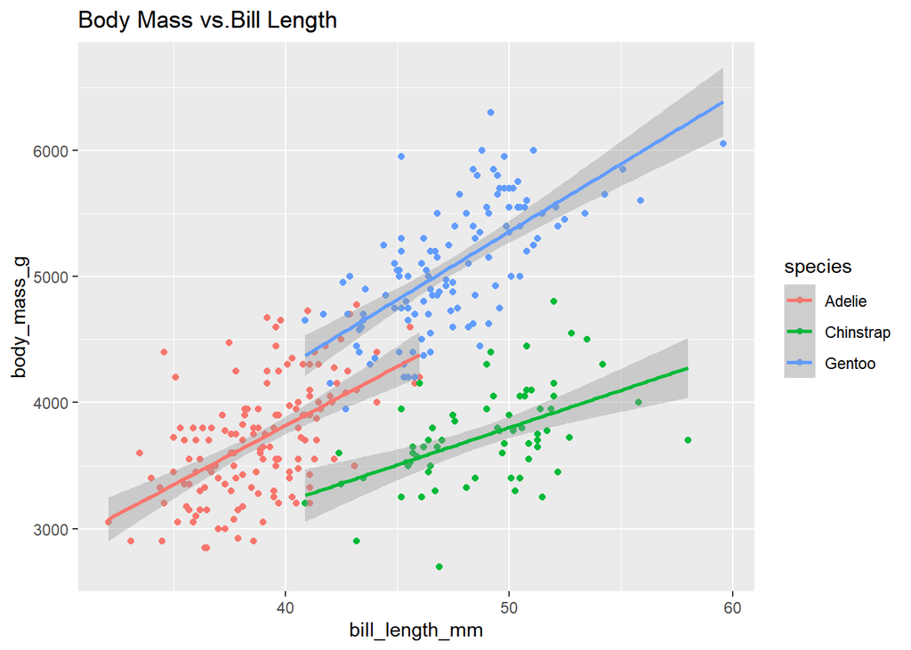

```r
ggplot(data = penguins2, mapping = aes(x= bill_length_mm,
  y=body_mass_g, color=species))  + geom_point() +
  labs(title = "Body Mass vs.Bill Length ") +
  geom_smooth(formula='y ~ x', method = "lm")
```

### Bill_Length and Bill Depth

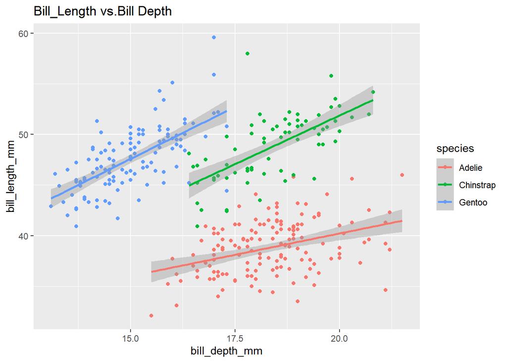

```r
ggplot(data = penguins2, mapping = aes(x= bill_depth_mm,
  y=bill_length_mm, color=species))  + geom_point() +
  labs(title = "Bill_Length vs.Bill Depth") +
  geom_smooth(formula='y ~ x', method = "lm")
```

## Conclusion

Adelie has the highest population of 146, with 73 females and 73 males. Gentoo followed with population of 119, with 58 females and 61 males. Chinstrap has the lowest population of 68, with 34 females and 34 males.

Adelie species were found on the three Islands(Torgersen, Dream, Biscoe), Gentoo species were only found on Biscoe Island and Chinstrap species were only be found on Dream Island.

From the relationship plots, we deduced the body features related positively with to each other.

- As the bill length increases, the bill depth increases.
- As the flipper length increases, the bill depth increases.
- As the flipper length increases the bill length increases.
- As the body mass increases, the bill length increases.
- As the body mass increases, the bill depth increases.
- As the body mass increases, the flipper length increases.

## Dataset Source

Data was collected by Dr. Kristen Gorman.